# Studying R Stan

R. Tanji

## Support Page

- [GitHub](https://github.com/MatsuuraKentaro/RStanBook)

## Chap 1 統計モデリングとStanの概要

### 統計モデリングとは

- 世の中の事象を、必要なエッセンスだけ取り出して描写すること
  - プラモデル：色や形を残して材質・機能を捨象
- 数式を用いてエッセンスを記述する：数理モデル
  - 確率モデル probabilistic model
- 統計モデリング：確率モデルをデータに当てはめて、現象の理解と予測を促す
  - 統計モデリングの要素
    - 確率分布
    - パラメータ
    - パラメータをつなぐ関係式
- モデル化にあたって捨象した要素の重要性を確認する

### 統計モデリングの目的

統計モデルの2つの目的

- 解釈
  - データの生成過程を理解する
  - 解釈可能なモデルをもとに、次のアクションを決める
- 予測

**頑健性**：解釈可能で予測精度の高いモデル

- 機械学習との違い：SVM: サポートベクターマシン、勾配ブースティング、ランダムフォレスト、…
  - 数式をモデリングするための背景知識が少なくても予測可能
  - 過学習が起こりやすい
- 古典的な分散分析、グループごとの集計との違い
  - 直感的で解釈しやすい
  - 対象に対する背景知識や経験を活用しきれない

→両者の性能を併せ持つ手法としての統計モデリング

### 確率的プログラミング言語

- 確率モデルのパラメータ推定における難点
  - 推定計算の数式導出
  - モデルの変化に対応した数値計算の実装
- プログラミング言語の登場により、これらの操作がより平易に
  - 多数のモデルを試行錯誤可能に

### なぜStanなのか

- これまで主流だったソフトウェア
  - WinBUGS
  - JAGS
- **Stan**
  - RStan
  - PythonやMATLABとも連携可能
  - **NUTS**: No-U-Turn Sampler
    - Hamiltonian Monte Carlo (HMC, MCMCの一種)の実装
    - パラメータの数が多い場合の効率的なサンプリング
    - 1ステップあたりの所要時間はその他の言語に比べて長いが、ステップ間の相関が低いため、従来よりも少ないステップで計算を完了することができる
    - 複雑なモデルのサンプリングも可能
  - その他、デバッグのしやすさ、マニュアルの詳細さなどの長所

### なぜRStanなのか

- Stanの性能とRの優れた可視化機能を連結
- 確率分布を使うモデルが容易に実装可能
- データ加工も容易

## Chap2 ベイズ推定の復習

### 伝統的な統計学(頻度論)の問題点

- 伝統的な統計学：パラメータ$\thetaが$ある一点の真値をもつ定数と考える
- 実用上の問題
  - 検定の解釈が直感的でない
  - 信頼区間の解釈が直感的でない
  - 複雑なモデルにおいて、信頼区間と予測区間の算出が難しい

### 尤度と最尤推定

モデルのあてはまりの評価

定式化されたモデル：「$Y[n] (n = 1, \ldots, 20)$は、$\text{Normal}(\mu, 1)に$従う」…推定すべきパラメータは$\mu$である

- 尤度: likelihood
  - パラメータ$\mu$に対する尤度関数：
  - $$L(\mu) = \prod_{n = 1}^N \text{Normal}(Y[n] | \mu, 1)$$
  - パラメータに条件づけたときのデータ$Y$が観測される確率
- 尤度が最も高くなるパラメータを探す推定法を最尤推定(maximum likelihood estimation)と呼ぶ
  - 推定値：maximum likelihood estimate
  - **パラメータは点推定される**
- 一般に、尤度は1未満の多数の数の積であるため、非常に小さな値を持つ。そのため、計算の煩雑さを避けるために対数を取る(対数尤度)
  - Rの`optim`関数や`{nlme}`パッケージに含まれる関数では、適当にパラメータの初期値を与え、その位置から対数尤度が最も大きく増加する方向にパラメータを動かし、収束するまで繰り返すステップで推定を行う

**最尤推定が対処しきれない問題**

- 過学習(overfitting)
  - (各グループごとの)観測が少数のサンプルに対する過剰な適合が経験に反する推定を正当化し、汎化性能(新しいデータに対する予測能力)を低下させる
- 最尤推定の実際の計算が難しくなる
  - 局所最適化が帯域最適化にならない可能性
  - 複数の初期値から推定を行うことである程度解決されるが、一方でパラメータが多数に及ぶ場合、十分な試行回数を稼ぐことが難しくなる

### ベイズ推定とMCMC

前節の問題を解決する方法の一つとして、

- ベイズ推定 Bayesian Inference
- マルコフ連鎖モンテカルロ法 Markov chain Monte Carlo methods

ベイズ推定では、すべてのパラメータを確率変数とみなして、その確率分布を想定する

- 特定のパラメータがある区間に入る確率を求める：直感的に解釈しやすい結果
  - パラメータの点推定ではなく、あるデータ$Yが$得られたときの分布$p(\theta | Y)$ が得られる：複数パラメータの場合は同時分布

**事後分布：posterior distribution**

MCMCサンプルを用いたアルゴリズムの手順

1. パラメータの初期値を適当に定めてMCMCサンプルを作成
2. MCMCサンプルから得られたパラメータの推定値をもとに、次のステップのMCMCサンプルを乱数によって作成
3. ステップからサンプルを得るごとにパラメータの値を更新していく
- Glossary
  - サンプル列：ステップ数に従って得られる値の系列
  - chain：初期値と乱数のシードを一つに定めたときに得られたサンプル列
  - トレースプロット：MCMCサンプルのパラメータの値を取った折れ線グラフ
  - バーンイン burn in
    - 初期値直後のサンプル列：初期値への依存が大きいため、あえてサンプリングせずに捨てる
    - 密度分布は、例えば200ステップ経過した後のパラメータのMCMCサンプルから作成する：事後分布
  - 当然分布が収束しないこともある
    - 典型的にはサンプル列の自己相関が高くなっている
    - 数ステップ中の値が次のステップの値に大きな影響を与えているため、実質的に新しいサンプリングが行われていない
    - 影響が軽微な場合は、**thinning** (ステップすべてをサンプリングせず、数回に1度だけサンプリングを行う)ことで収束可能性が改善されることがある
    - 収束していない分布をもとに解析を進めることは基本的に推奨されない
      - 再現性問題

### ベイズ信頼区間とベイズ予測区間

**ベイズ信頼区間**: Bayesian confidence interval

- 事後分布の両端から$\alpha / 2\%$の面積を切り取って残った中央部に対応する区間を$(1 - \alpha)\%$ベイズ信頼区間と呼ぶ
- MCMCを使って事後分布を推定した場合は、MCMCの分位点がそれに対応

ex.) 観測できる流星群の数

- ポアソン分布$\text{Poisson}(y | \theta) = \theta^y e^{-\theta} / y!$ に従う
  - 次の10分間に流れ星を$i$ 個観測する確率は？
  - 個々のパラメータではなく、新しいデータの**予測分布 predicitve distribution**を求める必要
1. 最尤推定の予測分布
   - データ$Y$ から得られたパラメータ$\hat{\theta}$ をモデルに代入する
   - $\hat{\theta} = 1.4$ ならば、$\text{Poisson}(y | 1.4) = \theta^y e^{-1.4} / y!$ . これに$y = 0, 1, \ldots, Kを$代入して分布を求める
2. ベイズ推定の予測分布
   - 得られたパラメータの事後分布$p(\theta | Y)$ で加重したデータの発生確率(確率モデル) $p(y | \theta)$を足し合わせたもの
   - $$p_{\text{pred}}(y | Y) = \int p(y | \theta) p(\theta | Y) d \theta$$
   - MCMCを利用する場合、パラメータの事後分布$p(\theta | Y)$ はMCMCサンプルとして求められる。$p(y | \theta)$ は既知なので(モデルを仮定しているので)、$\theta$ の積分をMCMCサンプルの和で置き換えて実行すると予測分布が求まる
   - $$p_{\text{pred}}(y | Y) = \sum_{i} p(y | \theta_i) \times p(\theta_i | Y)$$
     - ってことだよね？サンプリングは離散の値でしか出ないから
     - $i$はMCMCサンプルから観測されたそれぞれの$\theta$に対応

**ベイズ予測区間**: Bayesian prediction interval

- $p(\theta | Y)$ からのMCMCサンプルから値を一つ選択
- 選択したパラメータを$\theta^{\dagger}$ として、確率モデル$p(y | \theta^{\dagger})$ に従う乱数$y^{\dagger}$ を生成する
- 集積された$y^{\dagger}$は、予測分布$p_{\text{pred}}(y | Y)$からのMCMCサンプルとみなせる：予測区間の導出

**最尤推定によるデータへの過剰適合**

- モデルが複雑/データが不十分な場合、最尤推定で得られた予測分布はデータに過剰適合する
- 複雑なモデルの多くは尤度関数が(多変量)正規分布で近似することが難しく、予測分布が真の分布に一致しない

**事前分布**

- $$p(y | .) = \int p(y | \theta) p(\theta_i) d \theta$$
  - 観測されたデータの情報を使わない
  - 事前分布から予測分布：事前予測分布・ベイズ事前予測区間を算出することもできる

ベイズ信頼区間の利用

- パラメータの数が多いときに、事後分布を可視化して特徴を理解することが困難であるため、情報を落としてやる必要がある
- パラメータが少数なら分布をそのまま見てもよい

### 最尤推定とベイズ推定との関係

- **事後確率最大推定値**: maximum a posteriori estimate **MAP**
  - 事後分布$p(\theta | Y)$ を最大にする点$\theta^*$
- 事前分布$p(\theta)$ に十分に幅の広い一様分布や、裾の厚い正規分布を使うと、$p(\theta)$ は広い範囲で定数とみなせるので、
- $$\theta^* = \arg \max_{\theta} p(\theta | Y) = \arg \max_{\theta} [p(Y |
  \theta) p(\theta)] = \arg \max_{\theta} p(Y | \theta)$$
- が成り立つ。4項めは尤度に等しいので、得られた事後確率最大推定値は最尤推定量に一致する：伝統的な統計学とも整合性を持つ

### 事前分布の選択

ベイズ統計$\times$ MCMCの問題点

- 分布収束しないケースへの対処
- 事前分布の選択：複数の価値基準
  - **無情報事前分布**：主観的な分布選択による分析者間の結果の違い
  - **弱情報事前分布 weakly informative prior**：人間の身長を推定する際に、3メートルに正の確率を当てる必要はなかろう
  - **共役事前分布** **conjugate prior**：計算上の負荷を軽減するために用いられる。詳細は10章参照

#### cf.

- 最尤推定の問題点について
- ベイズ推定について
- ベイズ統計の歴史について
- MCMCアルゴリズムについて

## Chap 3 統計モデリングを始める前に

### データ解析の前準備

データ解析において、一般に必要となる前準備

- データ取得以前
  - 背景知識の収集
    - 該当分野で認められる仮定や利用される解析・可視化手法
  - 問題設定
    - リサーチクエスチョン
    - 主張したいこと
    - 分析のストーリー、それを伝える可視化
  - 解析計画
    - 手法選択やその結果を受けて行う解析のルートづくり
- データ取得後
  - 分布の確認
    - ヒストグラム
    - 2変数間の関係：散布図やクロス集計

前処理・描画ツール

- 描画ツール：Spotfire, R
- 集計・加工：R, SQL, Python, Ruby, …
- クリーニング：OpenRefine

### 統計モデリングの手順

1. 解析の目的
2. データの分布の確認
3. 背後にあるメカニズムの想像
4. モデル式の記述
5. Rによるシミュレーション
6. Stanによる実装
7. 推定結果の解釈
8. 図によるモデルのチェック
- モデルはシンプルなものから始める
  - 王道のモデルをコピー
  - 説明変数の数を絞る
  - 確率変数は各独立と仮定する
  - グループ差や個人差について考慮しない
- 計算負荷を落として分析の概形をつかむ
  - ランダムな抽出によるサンプルサイズの制限
  - 特定カテゴリーのデータを抽出して分析する
- その他、重要なステップ
  - 再現性のチェック
    - 頑健性：観測の間引き、モデルや事前分布の微細な変更が結果に大きな影響を及ぼさないか
    - 外敵妥当性
    - 使用するソフトやアルゴリズムの変更が影響しないか
    - 初期値・乱数の変更
  - データ解析のサイクル
    - 予測性能の改善・原因究明
    - 新しいデータの取得
    - データの充実による複雑なモデルの実装可能性

### 背景知識の役割

**逆問題** inverse problem

- 一部のインプットとアウトプットが分かっていて、その間をつなぐメカニズムが不明な場合
  - 答えを何通りも考えることができ、一意に定めることが不可能
    - **不良設定問題** ill-posed problem
- どの答えがもっともらしいかについては、背景知識をもとにした補完が必要である

**モデルの詳細さ**

- モデリングは問題設定によって変化する
- たとえ取得されたデータが同じであったとしても

### モデルの記述方法

**モデル式**: 確率変数やデータの関係を記述した数式の集まり

**グラフィカルモデル** graphical model：教科書参照して

**構造方程式モデリング** structual equation medeling

- グラフによる表現方法には数式が与えられないため、モデルに含まれる変数の数があまりに多くない限りは数式を用いた記述方法を用いるのが無難

### 情報量基準を使ったモデル選択

**情報量規準** Information Criterion

- 予測の精度を表す規準：AIC WAIC
- 真のモデルへの近さを表す規準：BIC WBIC

WBICはWAICよりもシンプルなモデルを好む傾向にある

この辺は何かしらのテキストを読んだ方がよさそう

- 情報量規準における注意点
  - 過学習：手元のデータへの過剰適合
    - クロスバリデーションでも過学習を回避することは難しい
  - モデルの探索と情報量規準の増減は別ベクトル：安易なモデル選択を招く恐れ

### cf.

- モデリング
- AIC
- StanによるWAIC、WBICの算出

## Chap 4 StanとRStanをはじめよう

### StanとRStanの準備

- Rtoolsのインストール
  - 内部でC++を利用、そのコンパイラが必要になる
  - PATH通しとく
- 起動

  ```r
  #install.packages("rstan")
  p_load(rstan)
  ```

### Stanの基本的な文法

以降、chap3.stanも参照してくれ

#### ブロック構成

```stan
data {
  データYの宣言
}

parameters {
  サンプリングしたいパラメータ\thetaの宣言
}

model {
  尤度関数p(Y|\theta)の記述
  事前分布p(\theta)の記述
}
```

- 各ブロックの中に情報を記述
- 値が決まっていない確率変数はすべてパラメータとして扱われる
- サンプリングのシステム
  - コードの実行→モデル式がC++のコードに変換され、コンパイルされてMCMCサンプリングが実行される
  - ブロックの順序を誤るとエラーが出るので注意

#### 文法の基礎

- 標準偏差の定まった：正規分布をデータに当てはめる問題
- モデル式4-1

$$\begin{align}
Y[n] & \sim \text{Normal}(\mu, 1) \text{ where } n = 1, \ldots, N \\
\mu & \sim \text{Normal}(0, 100)
\end{align}$$
- $N$は観測数に対応

- 未知のパラメータ$\mu$をデータから推定する
  - 無情報事前分布：平均ゼロ、標準偏差100の非常に平らな正規分布
- Stanコードによる表現

```stan
data {
  int N;
  real Y[N];
}

parameters {
  real mu;
}

model {
  for (n in 1:N) {
  Y[n] ~ normal(mu, 1);
  }
  mu ~ normal(0, 100)
}
```

- dataブロック：データの個数Nと観測されたデータYを宣言
  - int, realなどで変数のクラスを表現
  - `Y[1], Y[2], …, Y[N]`：観測単位
- modelブロック：事前分布の宣言: `mu ~ normal(0, 100)`
  - forループで繰り返しデータを抽出することを表現
  - 特に指定がない場合、十分に幅の広い一様分布が使用される
- parametersブロック：推定するパラメータを宣言
- その他
  - **最終行は必ず空の改行で終わる(コメントアウトもなし)**
  - コメントアウト：`//`か`/**/`で囲む(後者は複数行を挟める)
  - `#`は非推奨だが使えるらしい
  - 文法：BUGS言語と一部に違い、知らんからいい

#### コーディング規約

まあ変なことしなきゃいいんだけどね

1. インテンドちゃんとする
2. データの変数は大文字、パラメータを小文字で表現
3. ブロック間は1行空けて
4. 変数名は`_`でつなぐ(`snake_case`っていうらしい。対立概念に`camelCase`とか、まあRと一緒だな)
5. `~=`の間はスペース入れろ

### Stanの`lp__`と`target`

Stanのパラメータ探索

- 事後確率$p(\theta | Y) \propto p(Y | \theta) p(\theta)p(\theta | Y)$の高くなるパラメータを探す
- 効率を上げるために、実際には対数事後確率を見る
  $$\log p(\theta | Y) \propto \log p(Y | \theta) + \log p(\theta) +
  \text{constant}$$
- 対数事後確率をパラメータ$\theta$について偏微分した値によって決める
  - このため、各MCMCステップのパラメータ$\theta^*$におけるt対数事後確率の定数項以外の項：$\log p(Y | \theta^*) + \log p(\theta^*)$を保持しておく$=$`lp__`：log posterior という名前で保持している
  - 尤度と事前分布の記述によって`lp__`の関数形が決まる
- `target`
  - `lp__`$=\log p(Y | \theta^*)+\log p(\theta^*)$
  - サンプリングのプロセスにおいては、事前確率$\log(\theta^*)$に対して、尤度$\log p(Y|\theta)$ を(観測単位ごとに)繰り返し足し続けることになる
  - このプロセスを明示的に表現した記法: 2つの記述は同値になる

    ```stan
    model {
      for (n in 1:N) {
        Y[n] ~ normal(mu, 1);
      }
      mu ~ normal(0, 100)
    }
    ```

    ```stan
    model {
      for (n in 1:N) {
        target += normal_lpdf(Y[n] | mu, 1);
        /* target += x はtarget = target + x と同値
        /* N(mu, 1)からY[n]をドローする確率、N回分足し続ける：尤度 */
      }
      target += normal_lpdf(Y[n] | mu, 100)
      /* 事前分布 */
    }
    ```

- 高度な分析においては、あえて`target`を使った書き方が必要になることも

### 単回帰

StanとRStanの実用例

- 社員の年齢から年収を予測
  - 基本年収$y_{\text{base}}$ と観測不可能な影響$\varepsilon$ によって年収が決定される
  - $\varepsilon$ は平均0の正規分布に従う

#### 解析の目的

- B社に中途採用された50歳の社員の年収は？
- 年齢から年収を予測する問題
- 説明変数とか被説明変数とかはさすがに大丈夫でしょう

#### データの分布の確認

- 可視化されたデータから、線形モデルに無理がないか確認すべし

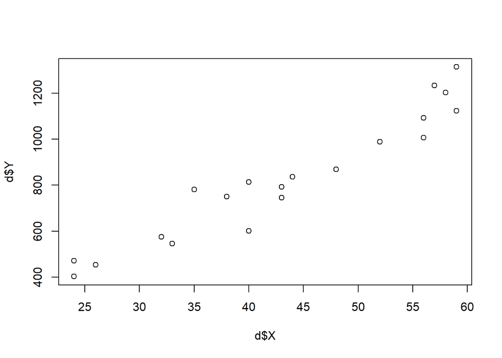

  - 線形関係でいけそう
    - そうなるように作ったデータだからね

#### モデル式の記述

**モデル式4-2**

$$\begin{align}
Y[n] &= y_{\text{base}}[n] + \varepsilon[n] \\
y_{\text{base}} &= a + b X[n] \\
\varepsilon[n] &\sim \text{Normal}(0, \sigma)
\end{align}$$

- $n = 1, 2, \ldots, N$
- $\varepsilon[n]$ は互いに独立、$\sigma$ がノイズの大きさに対応

ベイズ統計のモデリングに特有の仮定

- $\varepsilon$ だけでなく、$a, b, $ もそれぞれ確率変数である：$\theta$
- それぞれに対して無情報事前分布を仮定：十分に広い一様分布
  - 広い範囲で定数なので、事後確率の偏微分には干渉しない：モデルの中であえて宣言しなくてOK
- 以下、モデル式4-2の書き換え

**モデル式4-3**

$$\begin{align}
Y[n] &= a + b X[n] + \varepsilon[n] \\
\varepsilon[n] &\sim \text{Normal}(0, \sigma)
\end{align}$$

**モデル式4-4**

$$\begin{align}
y_{\text{base}}[n] &= a + b X[n] + \varepsilon[n] \\
Y[n] &\sim \text{Normal}(y_{\text{base}}[n], \sigma)
\end{align}$$

**モデル式4-5**

$$\begin{align}
Y[n] &\sim \text{Normal}(a + bX[n], \sigma)
\end{align}$$

- モデルの記述方法によって速度が異なることがあるらしい
  - $\varepsilon$を消去した方が速い
  - 収束しにくくなる場合もある
  - 一般的にはどのモデル式も等価

#### Rの`lm`関数で推定

シンプルなモデルにおいては、最尤推定とStanによるベイズ推定の予測分布にはほとんど差がない

- `lm`関数による直線のあてはめ

  ```r
  #d <- read_csv("../input/data-salary.txt") #もうやってるので省略
  res_lm <- d %>%
    lm(Y ~ X, data = .)
  res_lm
  ```

  ```
  ##
  ## Call:
  ## lm(formula = Y ~ X, data = .)
  ##
  ## Coefficients:
  ## (Intercept)            X
  ##      -119.7         21.9
  ```

- 予測区間と信頼区間の導出

  ```r
  X_new <- data.frame(X = 23:60)
  conf_95 <- predict(res_lm, X_new, interval = 'confidence', level = .95)
  pred_95 <- predict(res_lm, X_new, interval = 'prediction', level = .95)
  ```

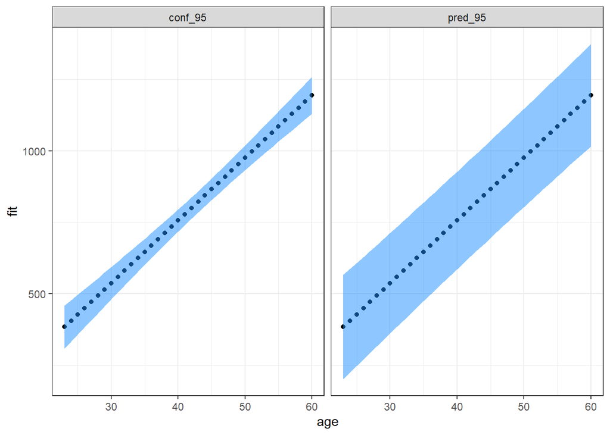

  めんどいしこんなもんでいいや

#### Stanで実装

stanコードの作成

```stan
data {
  int N;
  real X[N];
  real Y[N];
}

parameters {
  real a;
  real b;
  real<lower=0> sigma;
}

model {
  for (n in 1:N) {
  Y[n] ~ normal(a + b * X[n], sigma);
  }
}
```

- 実行はとりあえずスクリプトからやってみた方がいいかも
- 割とシンプルな計算でも時間食いそうなので：そんなことないのかもしれない
- rstanのパッケージバージョンを下げないと失敗します。インストールの方法は[ここ](https://developer.mamezou-tech.com/blogs/2022/06/30/install-rstan-on-r421/)を参照して下さい

サンプルデータの作成とstanファイルの実行

```r
#d <- read_csv("../input/data-salary.txt")
# もうやってるので省略

data <- list(
  N = nrow(d),
  X = d$X,
  Y = d$Y
)

#fit <- stan(file = "../stan/model4-5.stan", data = data, seed = 1234)
#fit <- stan(file = model4_4_5, data = data, seed = 1234)
fit <- sampling(test, data)

#save.image(file = "../output/result-model4-5.RData")
# 実行しなくてOK、推定結果の保存
```

```r
# RMarkdown上で何度も読むのは面倒なので、保存しているワークスペースを呼び出し
load(file = "../output/result-model4-5.RData")
```

**結果の確認**

```r
fit
```

```
## Inference for Stan model: anon_model.
## 4 chains, each with iter=2000; warmup=1000; thin=1;
## post-warmup draws per chain=1000, total post-warmup draws=4000.
##
##          mean se_mean    sd    2.5%     25%     50%    75%  97.5% n_eff Rhat
## a     -118.08    2.26 74.86 -262.05 -169.62 -119.70 -68.95  34.52  1095 1.00
## b       21.86    0.05  1.66   18.38   20.76   21.89  23.00  24.99  1114 1.00
## sigma   86.06    0.44 16.22   61.20   74.88   83.53  94.69 126.65  1381 1.00
## lp__   -93.68    0.04  1.35  -97.23  -94.28  -93.33 -92.70 -92.15  1117 1.01
##
## Samples were drawn using NUTS(diag_e) at Fri Mar 10 14:04:33 2023.
## For each parameter, n_eff is a crude measure of effective sample size,
## and Rhat is the potential scale reduction factor on split chains (at
## convergence, Rhat=1).
```

#### 収束診断をファイルへ出力する

MCMCが収束したと判断する根拠を保存し、報告する

- パラメータの要約
- トレースプロット

`ggmcmc`パッケージを利用：RStanでも描画可能だが、多くのパラメータを扱う場合に面倒なことが起こりやすい

```r
#p_load(ggmcmc)

frame_saved <- as_tibble(summary(fit)$summary) %>%
  mutate(variable = row.names(summary(fit)$summary)) %>%
  relocate(variable, before = 1) #tibble形式で結果をcsvに保存

frame_saved
```

```
## # A tibble: 4 × 11
##   variable before se_mean    sd `2.5%`  `25%`  `50%` `75%` `97.5%` n_eff  Rhat
##   <chr>     <dbl>   <dbl> <dbl>  <dbl>  <dbl>  <dbl> <dbl>   <dbl> <dbl> <dbl>
## 1 a        -118.   2.26   74.9  -262.  -170.  -120.  -69.0    34.5 1095.  1.00
## 2 b          21.9  0.0499  1.66   18.4   20.8   21.9  23.0    25.0 1114.  1.00
## 3 sigma      86.1  0.437  16.2    61.2   74.9   83.5  94.7   127.  1381.  1.00
## 4 lp__      -93.7  0.0404  1.35  -97.2  -94.3  -93.3 -92.7   -92.1 1117.  1.01
```

```r
#write_excel_csv(frame_saved, "output/fit_summary.csv")

#ggmcmc(
#  ggs(fit, inc_warmup = TRUE, stan_include_auxiliar = TRUE),
#  file = "output/fit_tracplot.pdf", plot = "traceplot"
#)

## PDFでの出力も可能

#出力
```

- trace plotから視覚的な収束判断を行う
- `ggmcmc`パッケージについては別途勉強して
  - `ggs_traceplot`, `ggs_density`
  - パラメータ数が増えるとメモリに負荷がかかるので

#### MCMCの設定変更

```r
library(pacman)
p_load(rstan)
p_load(tidyverse)

d <- read_csv("input/data-salary.txt")

data <- list(N = nrow(d), X = d$X, Y = d$Y)

# Stanファイルのコンパイルのみを行う
stanmodel <- stan_model(file = "stan/model4-5.stan")

# サンプリングのみを行う
fit <- sampling(
  stanmodel,
  data = data,
  pars = c("b", "sigma"),
  init = function() {
    list(
      a = runif(1, -10, 10), # 一様分布だっけ
      b = runif(1, 0, 10),
      sigma = 10
    )
  },
  seed = 123,
  chains = 3,
  iter = 1000,
  warmup = 200,
  thin = 2
)
```

- `stan`関数の実行をそれぞれの手順に分ける関数
  - `stan_model`, `sampling`
- モデルのコンパイルに時間がかかるので、オプションを変えながら繰り返しサンプリングを行いたい場合は両者を切り離した方が話が早い
- コンパイルしたモデルだけ.RDataファイルに保存しておいて、使うときに呼び出すことも可能

オプションの変更に係るスクリプトの記述方法

- MCMCサンプルを保存する変数の設定：`pars`引数
  - 一部の変数の推定結果のみに関心があるときに、結果を保存せず捨てることができる
    - 変数の収束診断が必要な場合は保存すべし
- 初期値の設定：`init`引数
  - 一部の変数だけ指定することも可能
  - 指定しない場合は $[-2, 2]$ の一様分布からドローした値が初期値として利用される
  - 局所最適がglobal optimalに対応しない場合、初期値をいじることで真値に近づくことが期待できる
- シードの設定：`seed`
  - ええやろ
- chains, iterations, warmup, thin
  - `chains`: 最低3、開発チームの推奨は4
  - `iter`: モデルの探索中は500-1000、 最終的なモデルが決まったら大きくする。1000-5000ほど
    - 事後平均の推定に求める精度とも相談：1桁細かく推定するために、追加で100倍のMCMCサンプルが必要となる (中心極限定理)
  - `warmup`: トレースプロットから視覚的に決める、一般的には100-500
  - `thin`: 通常1。Stanは他のソフトに比べて初期値への依存度が低いため、サンプル列の自己相関を抑えられる
    - 一時的に急激に値が変化するトレースプロットに対しては、`thin = 5`程度に設定して間引く
    - あまりに自己相関が高い場合は、モデルの再構築を検討する

#### 並列計算の実行方法

chainごとにサンプリングを並行して計算時間を短縮できる：各独立なので

- サンプリングの進捗やエラーの確認ができなくなり、デバッグがしづらくなるので、まずは並列化せずに回ることを確認してから行うのがよい

並列計算を指定するオプション

```r
rstan_options(auto_write = TRUE)
options(mc.cores = parallel::detectCores())
```

- `rstan_options(auto_write = TRUE)`: モデルのコンパイルを省略するため、ハードディスクにモデルファイルを保存する
- `options(mc.cores = parallel::detectCores())`: 並列計算の指定、ここではマシンのコア数をすべて使用して計算を行う

#### ベイズ信頼区間とベイズ予測区間の算出

`rstan::extract`: ベイズ信頼区間・ベイズ予測区間を計算するための値を推定結果から取り出す

- `tidyr`パッケージなどとコンフリクトするので、パッケージを明示しておく方が無難

```r
ms <- rstan::extract(fit)
```

- MCMCサンプリングからwarmingを除外した上で、残りをランダムに並べた値が出力される
  - シードの固定とも別の乱数がはたらいているらしい
  - 並び替えをしない、ウォームアップを含めるなどもオプションで指定可能